# R u Ready? HS2025 | Psychologie der Digitalisierung - Einheit 10

Sandra Grinschgl, Aaron Friedli, Lars Schilling

## R u Ready? Reproduzierbare Datenaufbereitung und -analyse mit R

HS 2025  
**LV-Leitung**: Dr. Sandra Grinschgl / MSc. Aaron Friedli  
**Tutor**: BSc. Lars Schilling  
**10. Einheit**, 19.11.2025

## Heute:

[interactive chart not shown]

## Muddiest Points!

[interactive chart not shown]

## Gruppe Sandra

Fortsetzung Datenqualität -> Folien EH 9

Zuerst Theorie, dann Hands-On

## Hands-on Block 5: Check In

Haben alle einen Long Datensatz (e.g. dat_full_long) mit 318 Zeilen = 2 Zeilen pro Versuchsperson?

Wenn nicht:

```r
dat_full_long <- dat_full |>
  pivot_longer(cols = c(pre1, pre4),
               names_to = "time_rating",
               values_to = "rating")
```

❗Falls ihr bis Ende Lektion noch nicht den LONG Datensatz erstellt und gespeichert habt - meldet euch bei uns

## Visualize: Tabellen

- Möglichkeit APA konforme Tabellen in R zu erstellen

**Schritt 1: Deskriptive Tabelle erstellen mit `summarize`**

```r
penguins_full <- drop_na(penguins)
penguins_summary <- penguins_full |>
  group_by(species) |>
  summarize(mean_body_mass = mean(body_mass_g),
            min_body_mass = min(body_mass_g),
            max_body_mass = max(body_mass_g)
            )

penguins_summary
```

```
# A tibble: 3 × 4
  species   mean_body_mass min_body_mass max_body_mass
  <fct>              <dbl>         <int>         <int>
1 Adelie             3706.          2850          4775
2 Chinstrap          3733.          2700          4800
3 Gentoo             5092.          3950          6300
```

## Visualize: Tabellen

**Schritt 2: `kable` auf deskriptive Tabelle anwenden**

```r
library(knitr)

penguins_summary |>
  kable(
    caption = "Summary of penguin body mass by species",
    digits = 1,
    col.names = c("Species", "Mean body mass (g)", "Min", "Max")
  )
```

Summary of penguin body mass by species

| Species | Mean body mass (g) | Min | Max |
| --- | --- | --- | --- |
| Adelie | 3706.2 | 2850 | 4775 |
| Chinstrap | 3733.1 | 2700 | 4800 |
| Gentoo | 5092.4 | 3950 | 6300 |

Weitere Formatierungen möglich, z.B. row.names, col.names…siehe Hilfefunktion

## [`apaTables`](https://dstanley4.github.io/apaTables/articles/apaTables.html) - APA konforme Tabellen von statistischen Analysen

Korrelationstabelle im APA Format –> Kann man auch für Regressionen und ANOVAs verwenden

**1.Schritt: Auswahl von Variablen**

```r
penguins_subset <- penguins |>
  select(bill_length_mm, bill_depth_mm, flipper_length_mm)
```

## [`apaTables`](https://dstanley4.github.io/apaTables/articles/apaTables.html) - APA konforme Tabellen von statistischen Analysen

**2.Schritt: Korrelationstabelle for ausgewählte Variablen**

Speichert Tabelle als Word Datei

```r
library(apaTables)
apa.cor.table(penguins_subset)
```

[figure not shown]

## Abbildungen: Visualize (Fortsetzung in EH 11)

[figure not shown]

## Visualisierungen: Reproduktion der Figures aus Grinschgl 2021

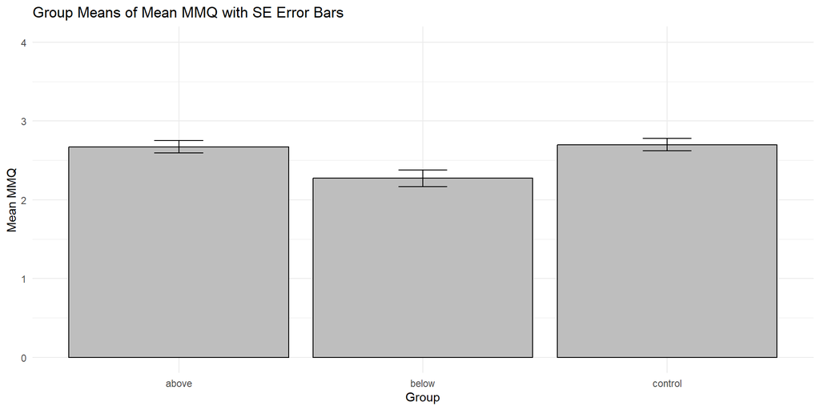

## Visualisierungen

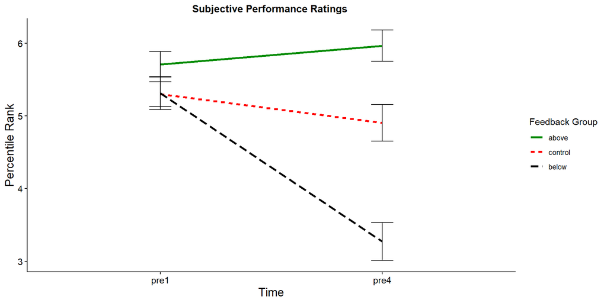

## `ggplot2()`

Sehr flexibles Paket.

- Plots werden schrittweise “befüllt”
- Alle plots beginnen mit `ggplot()` und dem verwendeten Datensatz
- Mit aes() definieren wir die elemantaren Elemente der Plots - Variablen die geplottet werden sollen
- mit + können wir geoms, layers und weitere Elemente hinzufügen.

## `ggplot2()` - Cheatsheet

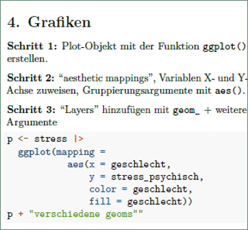

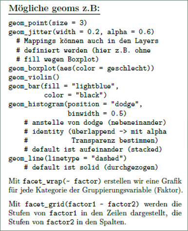

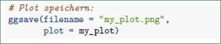

## Argumente von `ggplot()`

- Variablen als Aestheatic Mappings defineren
- Mapping ist immer das zweite argument, “call” kann also auch verkürzt werden.

```r
p <- penguins |>
  ggplot(
       mapping =
         aes(x = body_mass_g,
           y = bill_length_mm))
p
```

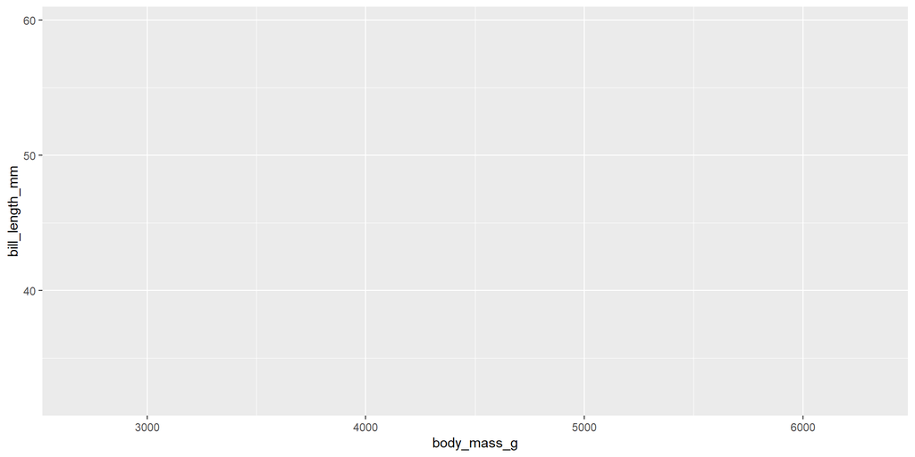

## `ggplot()` - Geoms

- Layers Hinzufügen z.B. ein geom mit +
- Geoms = geometrische Objekte, die die Daten darstellen (z.B. Punkte, Linien)
- Muss je nachdem welche Daten man hat und wie man diese darstellen will ausgewählt werden, z.B.
  - Kategoriale Variable: `geom_bar()`
  - Kontinuierliche Variable: `geom_histogram()`
  - 2 kontinuierliche Variablen: `geom_point()`, `geom_line()`
  - 2 Kategoriale Variablen: `geom_count()`
  - Kategorial + Kontinuierlich: `geom_boxplot()`, `geom_violin()`

```r
p <- p +
  geom_point()

p
```

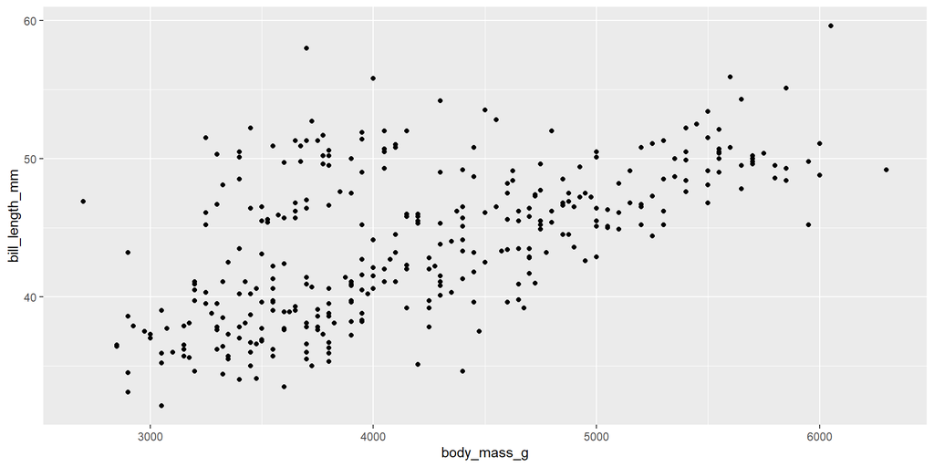

## `ggplot()` - Layers

- Mappings können auch in den Layers definiert werden

```r
p <- p +
  geom_point(aes(x = body_mass_g,
           y = bill_length_mm))

p
```

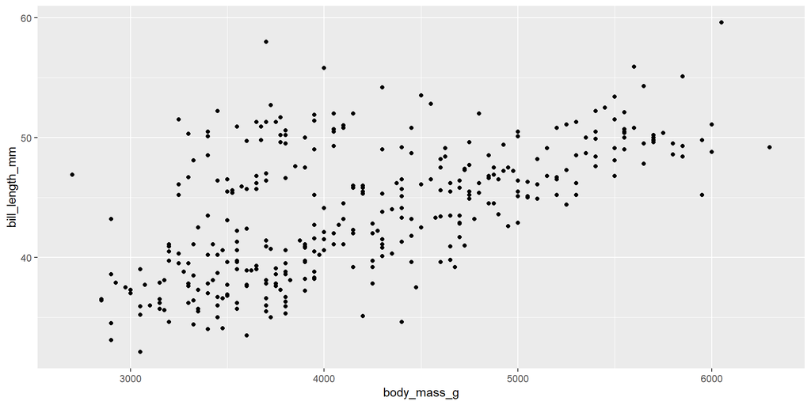

## `ggplot()` - Layers

- Titel + Achsenbeschriftung (= `labs`), Regressionslinien, vereinfachtes Design

```r
p <- p +
  geom_smooth(aes(group = 1), method = "lm") +
  theme_classic() +
  labs(
    title = "Relationship Between Body Mass and Bill Length",
    x = "Body Mass (g)",
    y = "Bill Length (mm)"
  )

p
```

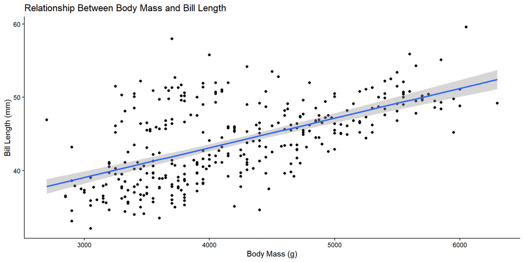

mit `theme_` können [verschiedene Formatierungen](https://ggplot2.tidyverse.org/reference/ggtheme.html) gewählt werden. `theme_classic` wird typischerweise für APA7 passende Formatierungen gewählt.

## `ggplot()` - Verschiedene Layers/Geoms kombiniert

```r
p2 <- penguins |>
  ggplot(aes(x = island, y = body_mass_g, color = island, shape = sex)) +
  geom_boxplot() +
  geom_jitter(alpha = 0.5)+
  theme_classic()+
  labs(
    title = "Body Mass Per Island and Species", x = "Island", y = "Body Mass (g)")
p2
```

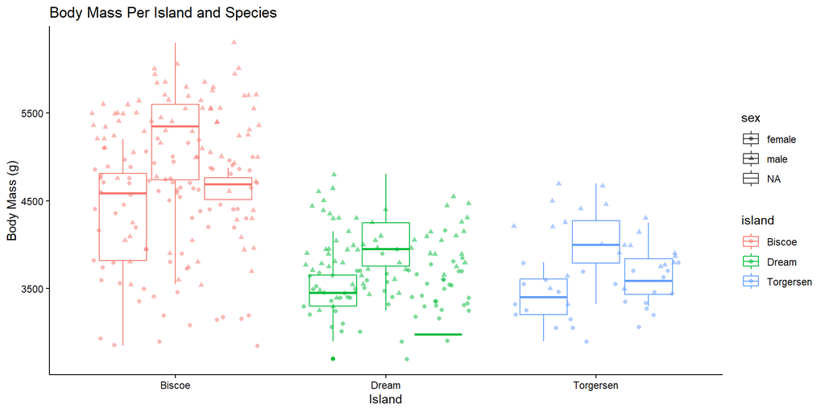

## Abbildungen speichern

```r
ggsave(filename = "my_first_plot.png", plot = p2)
```

## Weitere Ressourcen:

Viel, viel mehr Möglichkeiten als wir hier besprechen, siehe z.B.:

[**Auflistung von Argumenten**](https://ggplot2.tidyverse.org/reference/index.html)

[**ggplot2 Cheatsheet**](https://posit.co/wp-content/uploads/2022/10/data-visualization-1.pdf)

**R for Data Science – Kapitel 9 & 10:**  
[Kapitel „Layers“](https://r4ds.hadley.nz/layers)

[Kapitel „EDA“](https://r4ds.hadley.nz/EDA.html)

[**Weitere Textelemente in Abbildungen (Kapitel 11)**](https://r4ds.hadley.nz/communication)

Hier findet man auch weitere Visualisierungsmöglichkeiten & Informationen dazu, wie man verschiedene Plots neben/untereinander abbilden kann.

[Top 50 Visualisierungen mit ggplot2](https://r-statistics.co/Top50-Ggplot2-Visualizations-MasterList-R-Code.html#Waffle%20Chart)

[für Animationen, Signifikanztests, Wordclouds usw.](https://exts.ggplot2.tidyverse.org/gallery/)

## Heute haben wir:

- Muddiest Points besprochen
- Basics der Datenvisualisierungen kennengelernt
  - Erstellung von Tabellen
  - `ggplot()`

**Reminder: Beim Abschlussprojekt müsst ihr 1 Tabelle oder Abbildung nach Wahl zu den simulierten Daten abgeben.**

## R Hausübung 2

Abgabe bis Freitag **28.11.2025, 23:55**

Peerfeedback bis Mittwoch **03.12.2025 (vor der Einheit)**

**Achtung: Einhalten der Namensvorgaben!**